# Greenwashing, Customer ESG, and Supply-Chain Transparency

ESG and Finance Group

2026-10-19

# 1. Introduction

Greenwashing can reduce the reliability of corporate environmental, social, and governance (ESG) disclosures. Customer ESG expectations may influence suppliers’ disclosure practices and environmental behavior.

Customer pressure could encourage more substantive environmental improvements, potentially reducing greenwashing. Alternatively, it could encourage suppliers to emphasize favorable disclosures without equivalent improvements in environmental performance.

This project describes the relationship between customer ESG performance and supplier greenwashing, and examines whether the relationship differs across levels of supply-chain transparency.

The analysis is descriptive and does not establish causal relationships.

# 2. Data Description

The dataset comes from Chen and Tian (2025), *Greenwashing and Customer ESG Performance: The Moderating Effects of Corporate Transparency*.

Source: https://doi.org/10.17632/vwmj3yrt37.1

The original Stata file is stored in `data/raw/data.dta`.

The primary variables are:

- `GW`: Greenwashing index
- `CESG`: Customer ESG performance
- `sct_num`: Supply-chain transparency measure
- `GWA` and `CESGM`: Alternative measures
- `id` and `year`: Firm and year identifiers

# 3. Data Validation

The original dataset was imported using `haven`. We checked its dimensions, firm identifiers, year range, duplicate observations, and missing values.

```r
knitr::kable(
  data_summary,
  caption = "Table 1. Initial Data Validation"
)
```

Table 1. Initial Data Validation

| metric | value |
| --- | --- |
| Observations | 3709 |
| Variables | 34 |
| Unique firms | 997 |
| First year | 2009 |
| Last year | 2023 |
| Missing firm-year identifiers | 0 |
| Duplicate firm-year records | 0 |

The seven key research variables have no missing values. No original observations were deleted or imputed during the initial audit.

# 4. Panel Structure

The dataset is an unbalanced firm-year panel. We checked the observation years for each firm to identify gaps and consecutive-year pairs.

```r
knitr::kable(
  panel_summary,
  caption = "Table 2. Panel Structure"
)
```

Table 2. Panel Structure

| metric | value |
| --- | --- |
| Total firm-year observations | 3709 |
| Unique firms | 997 |
| Firms observed in only one year | 94 |
| Consecutive-year pairs | 2186 |
| Transitions with a panel gap | 526 |
| Missing years within observed firm spans | 1337 |

Only observations from consecutive years are used to calculate within-firm annual changes.

# 5. Aim 1: Annual Trends and Within-Firm Changes

## 5.1 Research Questions

How do greenwashing and customer ESG performance vary over time?

How are annual within-firm changes in customer ESG performance related to changes in greenwashing?

## 5.2 Annual Descriptive Statistics

The following table summarizes the annual mean and median of GW and CESG.

```r
knitr::kable(
  annual_trends,
  digits = 3,
  caption = "Table 3. Annual GW and CESG Statistics"
)
```

Table 3. Annual GW and CESG Statistics

| year | n_firms | mean_GW | median_GW | mean_CESG | median_CESG |
| --- | --- | --- | --- | --- | --- |
| 2009 | 245 | 0.002 | -0.020 | 4.215 | 4.250 |
| 2010 | 302 | 0.141 | 0.022 | 4.217 | 4.250 |
| 2011 | 414 | 0.045 | 0.006 | 4.439 | 4.500 |
| 2012 | 493 | -0.014 | -0.124 | 4.521 | 4.750 |
| 2013 | 480 | -0.061 | -0.267 | 4.410 | 4.250 |
| 2014 | 161 | 0.199 | -0.049 | 4.421 | 4.500 |
| 2015 | 198 | 0.262 | -0.004 | 4.475 | 4.750 |
| 2016 | 192 | 0.035 | -0.250 | 4.402 | 4.750 |
| 2017 | 202 | 0.234 | 0.000 | 4.559 | 4.750 |
| 2018 | 188 | 0.301 | 0.286 | 4.637 | 4.875 |
| 2019 | 174 | 0.504 | 0.294 | 4.619 | 4.750 |
| 2020 | 174 | 0.508 | 0.288 | 4.685 | 5.000 |
| 2021 | 203 | 0.238 | 0.046 | 4.371 | 4.250 |
| 2022 | 202 | 0.201 | 0.047 | 4.548 | 4.750 |
| 2023 | 81 | 0.063 | 0.046 | 5.059 | 5.000 |

## 5.3 Within-Firm Annual Changes

Annual changes were calculated only when the same firm was observed in two consecutive calendar years.

```r
knitr::kable(
  change_summary,
  digits = 4,
  caption = "Table 4. Within-Firm Annual Changes"
)
```

Table 4. Within-Firm Annual Changes

| variable | n_pairs | mean_change | median_change | sd_change |
| --- | --- | --- | --- | --- |
| GW | 2186 | 0.0097 | 0.0058 | 0.9778 |
| CESG | 2186 | 0.0321 | 0.0000 | 0.9686 |

## 5.4 Visualizations

The following figure compares the annual mean and median of greenwashing (GW). Both statistics are reported because the GW distribution contains relatively large positive values.

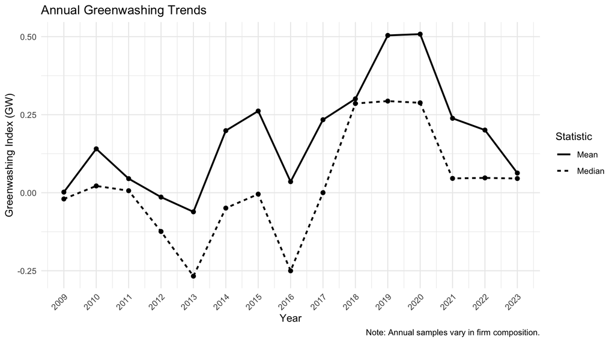

Figure 1. Annual Greenwashing Trends, 2009–2023

```r
library(ggplot2)

ggplot(annual_trends, aes(x = year)) +
  geom_line(
    aes(y = mean_GW, linetype = "Mean"),
    linewidth = 0.9
  ) +
  geom_line(
    aes(y = median_GW, linetype = "Median"),
    linewidth = 0.9
  ) +
  geom_point(aes(y = mean_GW), size = 1.8) +
  geom_point(aes(y = median_GW), size = 1.8) +
  scale_x_continuous(breaks = 2009:2023) +
  labs(
    title = "Annual Greenwashing Trends",
    x = "Year",
    y = "Greenwashing Index (GW)",
    linetype = "Statistic",
    caption = "Note: Annual samples vary in firm composition."
  ) +
  theme_minimal() +
  theme(
    axis.text.x = element_text(angle = 45, hjust = 1)
  )
```

The next figure presents the annual mean and median of customer ESG performance (CESG), allowing us to compare its temporal pattern with greenwashing.

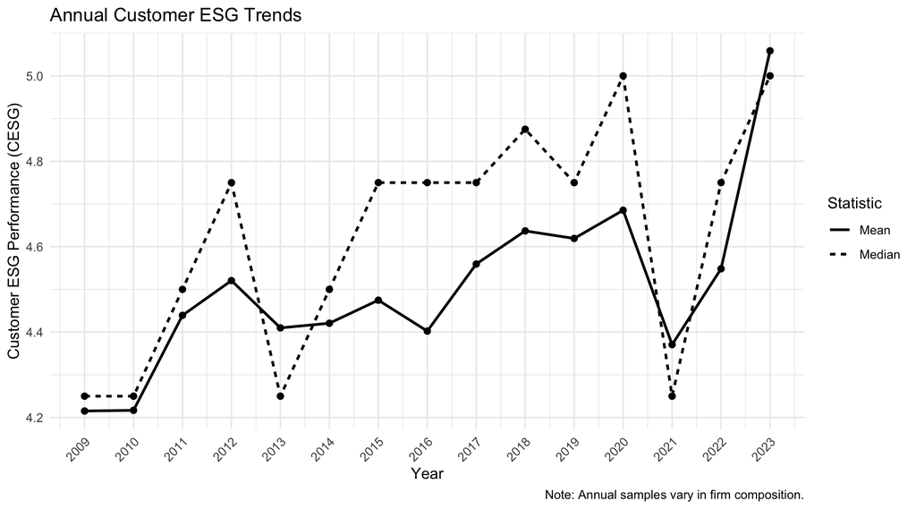

Figure 2. Annual Customer ESG Trends, 2009–2023

```r
ggplot(annual_trends, aes(x = year)) +
  geom_line(
    aes(y = mean_CESG, linetype = "Mean"),
    linewidth = 0.9
  ) +
  geom_line(
    aes(y = median_CESG, linetype = "Median"),
    linewidth = 0.9
  ) +
  geom_point(aes(y = mean_CESG), size = 1.8) +
  geom_point(aes(y = median_CESG), size = 1.8) +
  scale_x_continuous(breaks = 2009:2023) +
  labs(
    title = "Annual Customer ESG Trends",
    x = "Year",
    y = "Customer ESG Performance (CESG)",
    linetype = "Statistic",
    caption = "Note: Annual samples vary in firm composition."
  ) +
  theme_minimal() +
  theme(
    axis.text.x = element_text(angle = 45, hjust = 1)
  )
```

## 5.5 Association Between Within-Firm Annual Changes

To examine whether changes in customer ESG performance are associated with changes in supplier greenwashing, we compare the annual changes in CESG and GW for firms observed in consecutive years.

Pearson correlation describes their linear association, while Spearman correlation provides a rank-based measure that is less sensitive to extreme values.

```r
# Calculate correlations for consecutive-year pairs

complete_pairs <- firm_changes[
  complete.cases(
    firm_changes[, c("delta_GW", "delta_CESG")]
  ),
]

correlation_results <- data.frame(
  Statistic = c(
    "Pearson correlation",
    "Spearman correlation"
  ),
  Value = c(
    cor(
      complete_pairs$delta_CESG,
      complete_pairs$delta_GW,
      method = "pearson"
    ),
    cor(
      complete_pairs$delta_CESG,
      complete_pairs$delta_GW,
      method = "spearman"
    )
  ),
  N = nrow(complete_pairs)
)


# Export correlation results for reproducibility
write.csv(
  correlation_results,
  "results/tables/03_correlation_results.csv",
  row.names = FALSE
)


knitr::kable(
  correlation_results,
  digits = 4,
  caption = "Table 5. Association Between Annual Changes"
)
```

Table 5. Association Between Annual Changes

| Statistic | Value | N |
| --- | --- | --- |
| Pearson correlation | -0.1291 | 2186 |
| Spearman correlation | -0.1424 | 2186 |

The following scatterplot visualizes the relationship between annual changes in customer ESG and greenwashing. A fitted linear trend is shown for descriptive purposes. Small horizontal jitter is added to improve visibility where observations overlap.

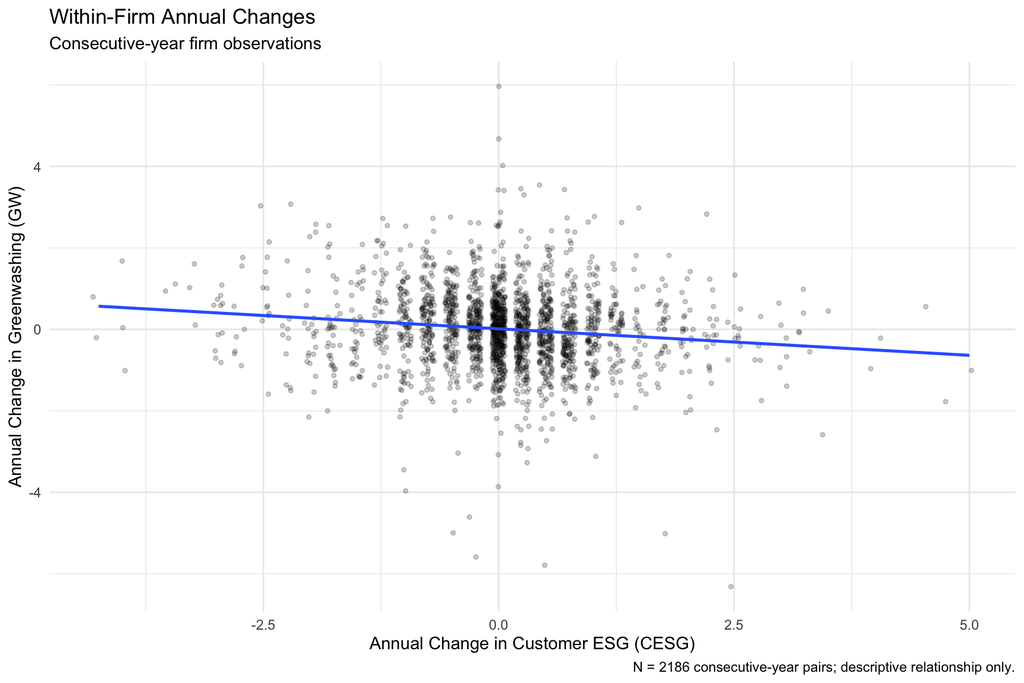

Figure 3. Within-Firm Annual Changes in Customer ESG and Greenwashing

```r
ggplot(
  complete_pairs,
  aes(x = delta_CESG, y = delta_GW)
) +
  geom_jitter(
    width = 0.07,
    height = 0,
    alpha = 0.2,
    size = 1
  ) +
  geom_smooth(
    method = "lm",
    se = FALSE,
    linewidth = 0.9
  ) +
  labs(
    title = "Within-Firm Annual Changes",
    subtitle = "Consecutive-year firm observations",
    x = "Annual Change in Customer ESG (CESG)",
    y = "Annual Change in Greenwashing (GW)",
    caption = paste(
      "N =", nrow(complete_pairs),
      "consecutive-year pairs; descriptive relationship only."
    )
  ) +
  theme_minimal()
```

## 5.6 Interpretation of Aim 1 Results

The descriptive analysis reveals several patterns in the relationship between customer ESG performance and supplier greenwashing.

First, annual greenwashing levels fluctuate substantially between 2009 and 2023. Mean GW reaches approximately 0.50 in both 2019 and 2020 before declining in subsequent years. The annual mean generally exceeds the median, consistent with the right-skewed distribution of GW.

Second, average customer ESG performance increases from approximately 4.22 in 2009 to 5.06 in 2023, although the trend is not consistently upward. Because the composition of firms differs across years, these annual averages should not be interpreted as changes within a fixed group of firms.

Third, among 2,186 consecutive-year firm observations, the mean annual changes in GW and CESG are approximately 0.0097 and 0.0321, respectively. Their median changes are 0.0058 and 0.0000.

The Pearson correlation between annual changes in CESG and GW is -0.1291, while the Spearman correlation is -0.1424. Both measures indicate a weak negative association.

These findings suggest that larger annual improvements in customer ESG performance tend to be associated with smaller increases or greater decreases in supplier greenwashing. However, the magnitude of this descriptive relationship is limited.

## 5.7 Limitations of Aim 1

Several limitations should be considered.

First, the panel is unbalanced, and the number of observed firms varies substantially across years. Changes in annual sample averages may therefore reflect differences in sample composition.

Second, within-firm annual changes are calculated only for consecutive-year observations. This avoids treating multi-year gaps as annual changes but limits the change analysis to 2,186 observation pairs.

Third, the greenwashing variable contains relatively large positive values, which may influence means and Pearson correlations. Medians and Spearman correlations are included as complementary descriptive measures.

Finally, the correlations do not establish causality. Other firm characteristics, common economic conditions, and repeated observations of the same firms may affect the observed association.

The analysis provides descriptive evidence rather than a causal estimate of the effect of customer ESG on supplier greenwashing.

# 6. Aim 2: Supply-Chain Transparency

## 6.1 Research Question

Does the descriptive relationship between customer ESG performance (CESG) and supplier greenwashing (GW) differ across levels of supply-chain transparency?

Unlike Aim 1, which examines within-firm annual changes, Aim 2 compares the levels of CESG and GW across firm-year observations.

## 6.2 Transparency Groups

The original transparency variable, sct_num, ranges from 0 to 10. Its distribution is concentrated at the two endpoints.

We use three groups:

- Group 0: sct_num = 0
- Group 1-9: sct_num between 1 and 9
- Group 10: sct_num = 10

Intermediate values are combined because they contain relatively few observations. This grouping preserves all observations and does not modify the original transparency variable.

```r
knitr::kable(
  sct_group_summary,
  digits = 3,
  caption = "Table 6. Descriptive Statistics by Transparency Group"
)
```

Table 6. Descriptive Statistics by Transparency Group

| transparency_group | n_observations | n_firms | mean_GW | median_GW | mean_CESG | median_CESG |
| --- | --- | --- | --- | --- | --- | --- |
| 0 | 2089 | 774 | -0.014 | -0.114 | 4.395 | 4.25 |
| 1-9 | 182 | 89 | 0.030 | -0.099 | 4.600 | 4.75 |
| 10 | 1438 | 485 | 0.358 | 0.157 | 4.550 | 4.75 |

## 6.3 CESG-GW Associations by Transparency Group

We calculate Pearson and Spearman correlations separately for each transparency group.

We also calculate a descriptive linear slope to compare the direction and magnitude of the fitted relationship.

```r
knitr::kable(
  sct_association,
  digits = 4,
  caption = "Table 7. CESG-GW Associations by Transparency Group"
)
```

Table 7. CESG-GW Associations by Transparency Group

| transparency_group | n_observations | n_firms | sd_CESG | pearson_r | spearman_r | linear_slope |
| --- | --- | --- | --- | --- | --- | --- |
| 0 | 2089 | 774 | 0.8988 | -0.2372 | -0.2751 | -0.3277 |
| 1-9 | 182 | 89 | 1.1065 | -0.1706 | -0.2096 | -0.1932 |
| 10 | 1438 | 485 | 1.0425 | -0.0344 | -0.0491 | -0.0484 |

## 6.4 Visualization of Group-Specific Associations

The following figure displays GW against CESG separately for the three transparency groups.

Each panel uses the same axis scales to support visual comparison. The fitted lines represent descriptive linear relationships, not causal effects.

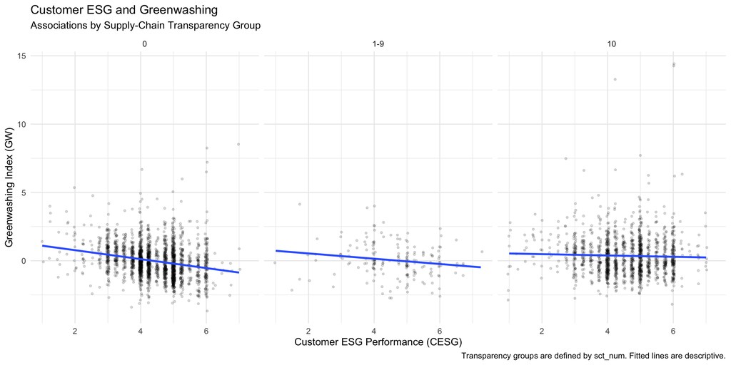

```r
library(ggplot2)

plot_data <- aim2_data %>%
  mutate(
    transparency_group = factor(
      transparency_group,
      levels = c("0", "1-9", "10")
    )
  )

ggplot(
  plot_data,
  aes(x = CESG, y = GW)
) +
  geom_jitter(
    width = 0.04,
    height = 0,
    alpha = 0.15,
    size = 0.8
  ) +
  geom_smooth(
    method = "lm",
    se = FALSE,
    linewidth = 1
  ) +
  facet_wrap(
    ~ transparency_group,
    nrow = 1
  ) +
  labs(
    title = "Customer ESG and Greenwashing",
    subtitle = "Associations by Supply-Chain Transparency Group",
    x = "Customer ESG Performance (CESG)",
    y = "Greenwashing Index (GW)",
    caption = paste(
      "Transparency groups are defined by sct_num.",
      "Fitted lines are descriptive."
    )
  ) +
  theme_minimal()
```